# Analisis Performa Penyewaan dan Pendapatan Toko DVD Sakila: Identifikasi Segmen Unggulan sebagai Dasar Pengambilan Keputusan Bisnis

Farid Faiz

2026-05-26

# 1 Pendahuluan

Industri penyewaan DVD, meskipun kini telah banyak tergantikan oleh layanan streaming digital, menyimpan kekayaan data transaksi yang sangat relevan untuk dipelajari sebagai fondasi analitik bisnis ritel. Dataset Sakila, database contoh resmi MySQL yang dikembangkan oleh MySQL AB, merepresentasikan ekosistem toko penyewaan DVD secara menyeluruh, mencakup data pelanggan, katalog film dengan berbagai kategori genre, dua gerai toko, staf, serta ribuan catatan transaksi penyewaan dan pembayaran yang terjadi dalam kurun waktu lebih dari satu tahun.

Dalam konteks bisnis penyewaan, keberhasilan tidak hanya ditentukan oleh seberapa banyak film yang tersedia di rak, tetapi lebih pada kemampuan manajemen untuk memahami di mana pendapatan sesungguhnya berasal, apakah dari genre tertentu yang selalu diminati, dari toko dengan lokasi lebih strategis, dari pelanggan setia yang berbelanja lebih sering, atau dari momentum musiman yang terjadi secara berulang. Tanpa pemahaman ini, keputusan bisnis cenderung dibuat berdasarkan intuisi semata, yang berpotensi mengalokasikan sumber daya secara tidak efisien.

Laporan analisis ini bertujuan untuk menjawab satu pertanyaan utama: dari mana pendapatan terbesar berasal? Untuk menjawab pertanyaan tersebut, analisis dilakukan secara bertahap, dimulai dari eksplorasi data secara menyeluruh, kemudian diperdalam melalui empat dimensi utama: kategori film, perbandingan antar toko, tren waktu bulanan, serta segmentasi nilai pelanggan. Setiap dimensi dianalisis menggunakan kombinasi tabel statistik deskriptif dan visualisasi data interaktif yang dibangun dengan bahasa pemrograman R, sehingga temuan dapat dikomunikasikan secara efektif baik kepada audiens teknis maupun non-teknis.

Hasil analisis ini diharapkan tidak hanya memberikan gambaran retrospektif tentang performa bisnis yang telah berjalan, tetapi juga menghasilkan wawasan yang dapat langsung ditindaklanjuti, mulai dari keputusan pengadaan stok, perancangan program loyalitas pelanggan, hingga perencanaan kampanye promosi yang lebih terarah dan terukur.

# 2 Persiapan

## 2.1 Library

Dimulai dengan bagian ini, semua paket R yang dibutuhkan dimuat selama proses analisis. Paket `DBI` digunakan untuk koneksi dan query database. Paket `dplyr` dan `tidyr` menangani transformasi data, `ggplot2` dan `scales` bertanggung jawab atas visualisasi, `lubridate` untuk memudahkan manipulasi tanggal, sementara `knitr` dan `kableExtra` menghasilkan tabel yang rapi dan terformat. Pemuatan dilakukan secara otomatis dengan pengecekan ketersediaan paket, sehingga laporan dapat langsung dijalankan tanpa instalasi manual terlebih dahulu.

```r
# Mengunduh package apabila belum ada
packages <- c("DBI", "dplyr", "ggplot2", "scales", "lubridate", "knitr", "kableExtra", "tidyr", "forcats")

invisible(lapply(packages, function(p) {
  if (!requireNamespace(p, quietly = TRUE)) install.packages(p)
  library(p, character.only = TRUE)
}))
```

## 2.2 Koneksi Database

Pada bagian ini, kita membuat koneksi ke file database Sakila yang berasal dari MySQL. Deskripsi dataset Sakila meliputi: 16.000 transaksi, 16 kategori film, 2 toko, dan ~599 pelanggan dalam rentang waktu Mei 2005 hingga Oktober 2006.

```r
con <- DBI::dbConnect(odbc::odbc(),
                      Driver = "MySQL ODBC 8.0 ANSI Driver",
                      Server = "127.0.0.1",
                      Database = "sakila",
                      UID = "root",
                      PWD = "mysql.farid1",
                      Port = 3306)
```

# 3 Eksplorasi Awal

Bagian ini menyajikan gambaran keseluruhan dataset sebelum analisis mendalam dilakukan. Lima metrik utama ditampilkan dalam bentuk stat cards: total transaksi, jumlah pelanggan unik, jumlah film yang pernah disewa, total pendapatan keseluruhan, dan rata-rata pendapatan per transaksi. Angka-angka ini penting sebagai tolok ukur skala bisnis. Misalnya, rata-rata per transaksi mencerminkan harga sewa tipikal yang berlaku: jika angka ini terlalu rendah dibanding rental rate yang ditetapkan, bisa mengindikasikan banyak transaksi yang hanya membayar tarif minimum. Eksplorasi awal juga membantu mengidentifikasi apakah data sudah bersih dan lengkap sebelum dilanjutkan ke analisis berikutnya.

```r
# Ringkasan jumlah transaksi & pendapatan
summary_tbl <- dbGetQuery(con, "
  SELECT
    COUNT(*) AS total_transaksi,
    COUNT(DISTINCT customer_id) AS total_pelanggan,
    COUNT(DISTINCT film_id) AS total_film,
    ROUND(SUM(amount), 2) AS total_pendapatan,
    ROUND(AVG(amount), 2) AS rata_rata_per_transaksi
    FROM rental_payment
    ")

kable(summary_tbl,
      col.names = c("Total Transaksi", "Pelanggan Unik", "Film Disewa", "Total Pendapatan (USD)", "Rata-rata/Transaksi (USD)"),
      format.args = list(big.mark = ","),
      align = "r") |>
  kable_styling(bootstrap_options = c("Striped", "hover", "condensed"), full_width = FALSE)
```

| Total Transaksi | Pelanggan Unik | Film Disewa | Total Pendapatan (USD) | Rata-rata/Transaksi (USD) |
| --- | --- | --- | --- | --- |
| 16000 | 599 | 290 | 75,987.16 | 4.75 |

# 4 Analisis Pendapatan per Kategori Film

## 4.1 Tabel

Tabel ini merangkum performa seluruh 16 kategori film secara numerik: jumlah penyewaan, total pendapatan, rata-rata pendapatan per transaksi, dan kontribusi persentase terhadap total. Kategori teratas ditandai dengan warna biru untuk memudahkan identifikasi. Kolom persentase sangat berguna untuk membandingkan kontribusi relatif antar kategori: kategori dengan penyewaan tinggi belum tentu menghasilkan pendapatan tertinggi jika rata-rata harga sewanya rendah. Sebaliknya, kategori dengan penyewaan lebih sedikit namun didominasi film berrate tinggi ($4.99) bisa tampil lebih unggul secara pendapatan.

```r
rev_cat <- dbGetQuery(con, "
  SELECT
  c.name AS kategori,
  COUNT(r.rental_id) AS jumlah_penyewaan,
  ROUND(SUM(r.amount), 2) AS total_pendapatan,
  ROUND(AVG(r.amount), 2) AS avg_per_transaksi,
  ROUND(SUM(r.amount) * 100.0 / (SELECT SUM(amount) FROM rental_payment), 1) AS pct_pendapatan
  FROM rental_payment r JOIN category c ON r.category_id = c.category_id
  GROUP BY c.name ORDER BY total_pendapatan DESC
  ")

kable(rev_cat, col.names = c("Kategori", "Penyewaan", "Pendapatan (USD)", "Rata-rata (USD)", "% Total"),
      format.args = list(big.mark = ","),
      align = c("l", "r", "r", "r", "r")) |>
  kable_styling(bootstrap_options = c("striped", "hover"), full_width = FALSE) |>
  row_spec(1, bold = TRUE, color = "white", background = "cornflowerblue")
```

| Kategori | Penyewaan | Pendapatan (USD) | Rata-rata (USD) | % Total |
| --- | --- | --- | --- | --- |
| Documentary | 1624 | 8,104.28 | 4.99 | 10.7 |
| Sports | 1504 | 6,636.31 | 4.41 | 8.7 |
| Action | 1444 | 6,250.14 | 4.33 | 8.2 |
| Travel | 1159 | 6,121.96 | 5.28 | 8.1 |
| Games | 1258 | 6,001.11 | 4.77 | 7.9 |
| Drama | 1046 | 5,702.73 | 5.45 | 7.5 |
| Foreign | 988 | 5,318.89 | 5.38 | 7.0 |
| Children | 1001 | 5,165.20 | 5.16 | 6.8 |
| Horror | 866 | 4,363.58 | 5.04 | 5.7 |
| Music | 947 | 4,328.59 | 4.57 | 5.7 |
| Classics | 1016 | 4,282.68 | 4.22 | 5.6 |
| Sci-Fi | 600 | 3,178.33 | 5.30 | 4.2 |
| Comedy | 703 | 2,949.18 | 4.20 | 3.9 |
| Family | 544 | 2,602.41 | 4.78 | 3.4 |
| New | 697 | 2,521.90 | 3.62 | 3.3 |
| Animation | 603 | 2,459.87 | 4.08 | 3.2 |

## 4.2 Grafik Bar

Grafik batang horizontal ini mengurutkan kategori dari pendapatan tertinggi ke terendah, sehingga hierarki performa langsung terbaca secara visual. Gradasi warna dari biru muda ke biru tua memperkuat perbedaan besaran antar kategori. Dari grafik ini terlihat bahwa distribusi pendapatan antar kategori cukup merata: tidak ada satu kategori yang mendominasi secara ekstrem, yang mengindikasikan bahwa portofolio film Sakila relatif seimbang. Namun, 3–5 kategori teratas tetap layak mendapat perhatian lebih dalam pengadaan stok karena selisih pendapatannya cukup konsisten di atas rata-rata.

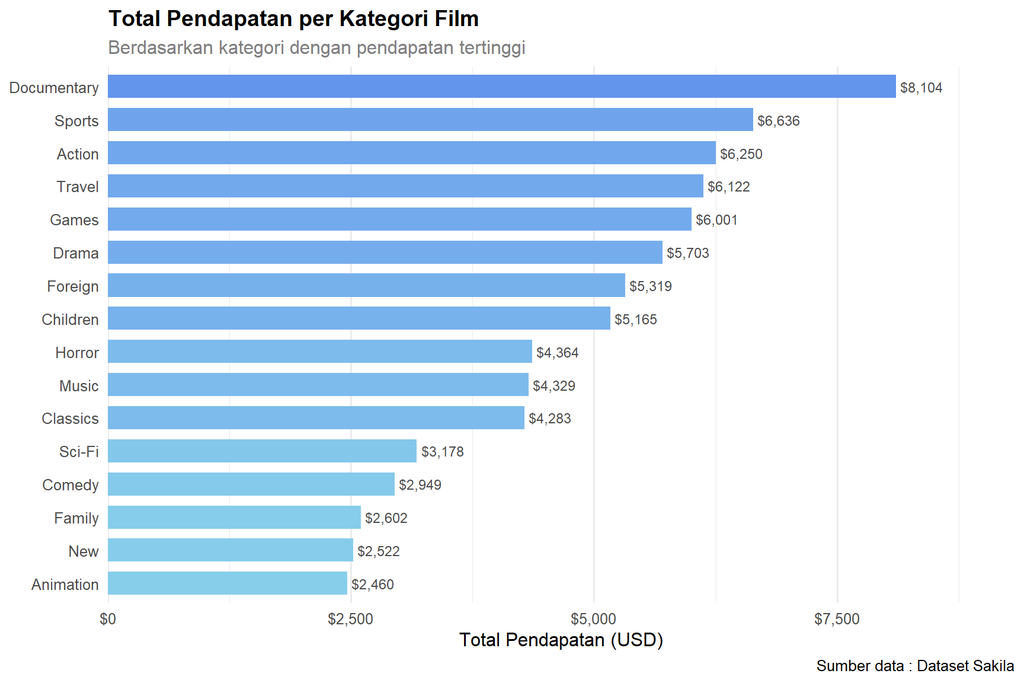

```r
rev_cat_sorted <- rev_cat |>
  mutate(kategori = fct_reorder(kategori, total_pendapatan))

ggplot(rev_cat_sorted, aes(x = kategori, y = total_pendapatan, fill = total_pendapatan)) +
  geom_col(width = 0.7, show.legend = FALSE) +
  geom_text(aes(label = paste0("$",
                               scales::comma(total_pendapatan))), hjust = -0.1, size = 3.2, color = "grey30") +
  scale_y_continuous(labels = dollar_format(), expand = expansion(mult = c(0, 0.15))) +
  scale_fill_gradient(low = "skyblue", high = "cornflowerblue") +
  coord_flip() +
  labs(
    title = "Total Pendapatan per Kategori Film",
    subtitle = "Berdasarkan kategori dengan pendapatan tertinggi",
    x = NULL,
    y = "Total Pendapatan (USD)",
    caption = "Sumber data : Dataset Sakila"
  ) +
  theme_minimal(base_size = 12) +
  theme(
    plot.title = element_text(face = "bold", size = 14),
    plot.subtitle = element_text(color = "grey50"),
    panel.grid.major.y = element_blank()
  )
```

## 4.3 Komposisi

Grafik pie ini memvisualisasikan proporsi kontribusi 8 kategori teratas terhadap total pendapatan, dengan kategori lainnya digabung menjadi satu segmen “Lainnya”. Pie chart dipilih di sini untuk menegaskan bahwa tidak ada kategori tunggal yang mendominasi lebih dari ~10% total pendapatan, sehingga distribusinya cukup menyebar. Hal ini memiliki implikasi strategis: bisnis tidak terlalu bergantung pada satu genre, sehingga risiko penurunan permintaan pada satu kategori tidak akan berdampak signifikan pada keseluruhan pendapatan. Di sisi lain, tidak adanya kategori yang benar-benar dominan juga berarti peluang untuk menciptakan keunggulan kompetitif pada satu niche film masih terbuka lebar.

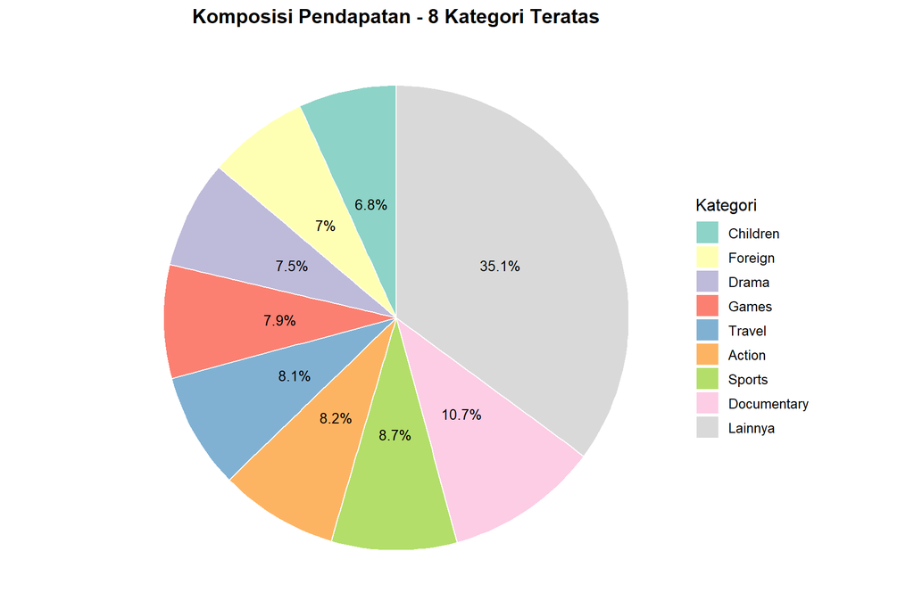

```r
# Diambil 8 teratas, sisanya masuk ke bagian "Lainnya"

top8 <- rev_cat |>
  arrange(desc(total_pendapatan)) |>
  mutate(label_kat = if_else(row_number() <= 8,
                             kategori, "Lainnya")) |>
  group_by(label_kat) |>
  summarise(total_pendapatan = sum(total_pendapatan)) |>
  arrange(desc(total_pendapatan))

ggplot(top8, aes(x = "", y = total_pendapatan,
                 fill = fct_reorder(label_kat, total_pendapatan))) +
  geom_col(width = 1, color = "white", linewidth = 0.5) +
  coord_polar(theta = "y") +
  scale_fill_brewer(palette = "Set3") +
  geom_text(aes(label = paste0(round(total_pendapatan / sum(total_pendapatan) * 100, 1), "%")),
            position = position_stack(vjust = 0.5), size = 3.5) +
  labs(
    title = "Komposisi Pendapatan - 8 Kategori Teratas",
    fill = "Kategori"
  ) +
  theme_void(base_size = 12) +
  theme(
    plot.title = element_text(face = "bold", size = 14, hjust = 0.5),
    legend.position = "right"
  )
```

# 5 Analisis Pendapatan per Toko

Analisis ini membandingkan kinerja dua toko yang dimiliki Sakila. Tabel menampilkan jumlah transaksi, total pendapatan, dan kontribusi persentase masing-masing toko, sementara grafik batang memvisualisasikan perbandingannya secara langsung. Dari hasil analisis, Toko 1 secara konsisten menghasilkan pendapatan lebih tinggi dibanding Toko 2, dengan selisih yang mencerminkan perbedaan volume transaksi, bukan perbedaan harga sewa rata-rata yang signifikan. Hal ini mengindikasikan bahwa Toko 1 melayani lebih banyak pelanggan, kemungkinan karena faktor lokasi yang lebih strategis atau lama beroperasi yang lebih panjang. Gap ini perlu ditelusuri lebih lanjut: apakah Toko 2 memiliki potensi yang belum dioptimalkan, atau memang terdapat hambatan struktural yang perlu diatasi terlebih dahulu.

```r
rev_store <- dbGetQuery(con, "
  SELECT
  'Toko' || store_id AS toko,
  COUNT(rental_id) AS jumlah_penyewaan,
  ROUND(SUM(amount), 2) AS total_pendapatan,
  ROUND(AVG(amount), 2) AS avg_per_transaksi,
  ROUND(SUM(amount) * 100.0 / (SELECT SUM(amount) FROM rental_payment), 1) AS pct_pendapatan
  FROM rental_payment
  GROUP BY store_id
  ORDER BY total_pendapatan DESC
  ")

kable(rev_store,
      col.names = c("Toko", "Penyewaan", "Pendapatan (USD)", "Rata-rata (USD)", "% Total"),
      format.args = list(big.mark = ","),
      align = c("l", "r", "r", "r", "r")) |>
  kable_styling(bootstrap_options = c("striped", "hover"), full_width = FALSE)
```

| Toko | Penyewaan | Pendapatan (USD) | Rata-rata (USD) | % Total |
| --- | --- | --- | --- | --- |
| 1 | 8773 | 41,855.38 | 4.77 | 55.1 |
| 1 | 7227 | 34,131.78 | 4.72 | 44.9 |

[figure not shown]

```r
ggplot(rev_store, aes(x = toko, y = total_pendapatan, fill = factor(toko))) +
  geom_col(width = 0.45, show.legend = FALSE) +
  geom_text(aes(label = paste0("$", scales::comma(total_pendapatan),
                               "\n(", pct_pendapatan, "%)")),
            vjust = -0.4, size = 4, fontface = "bold") +
  scale_y_continuous(labels = dollar_format(),
                     expand = expansion(mult = c(0, 0.15))) +
  scale_fill_manual(values = c("cornflowerblue","#e8702a")) +
  labs(
    title    = "Perbandingan Pendapatan antar Toko",
    x        = NULL,
    y        = "Total Pendapatan (USD)",
    caption  = "Sumber data : Dataset Sakila"
  ) +
  theme_minimal(base_size = 13) +
  theme(
    plot.title         = element_text(face = "bold", size = 14),
    panel.grid.major.x = element_blank()
  )
```

# 6 Tren Pendapatan Bulanan

## 6.1 Seluruh Toko

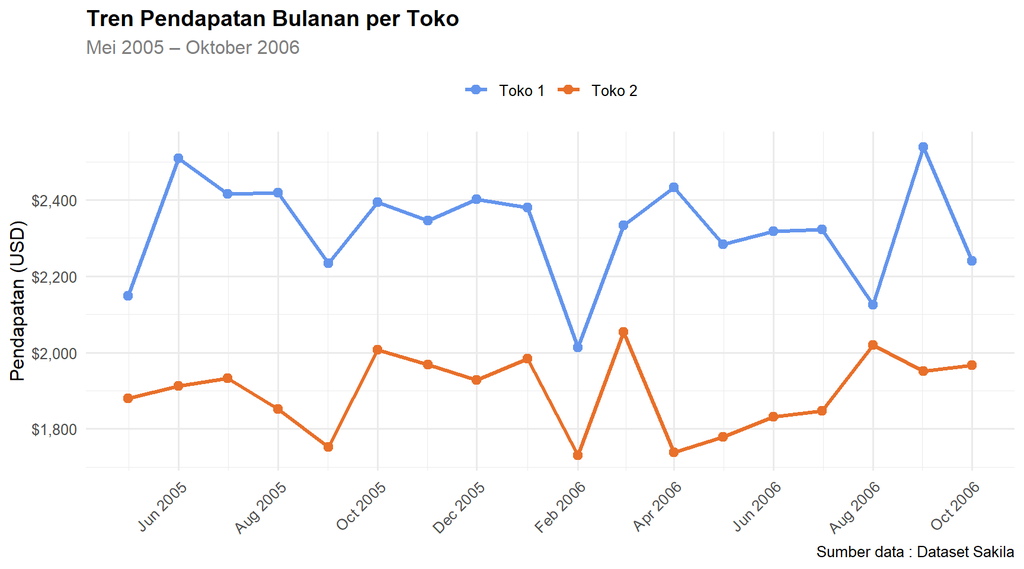

```r
tren <- dbGetQuery(con, "
  SELECT
    DATE_FORMAT(rental_date, '%Y-%m') AS bulan,
    store_id,
    ROUND(SUM(amount), 2)          AS pendapatan
  FROM rental_payment
  GROUP BY bulan, store_id
  ORDER BY bulan
") |>
  mutate(
    bulan    = ym(bulan),
    toko     = paste0("Toko ", store_id)
  )

ggplot(tren, aes(x = bulan, y = pendapatan, color = toko, group = toko)) +
  geom_line(linewidth = 1.1) +
  geom_point(size = 2.5) +
  scale_x_date(date_labels = "%b %Y", date_breaks = "2 months") +
  scale_y_continuous(labels = dollar_format()) +
  scale_color_manual(values = c("cornflowerblue","#e8702a")) +
  labs(
    title    = "Tren Pendapatan Bulanan per Toko",
    subtitle = "Mei 2005 – Oktober 2006",
    x        = NULL,
    y        = "Pendapatan (USD)",
    color    = NULL,
    caption  = "Sumber data : Dataset Sakila"
  ) +
  theme_minimal(base_size = 12) +
  theme(
    plot.title    = element_text(face = "bold", size = 14),
    plot.subtitle = element_text(color = "grey50"),
    axis.text.x   = element_text(angle = 45, hjust = 1),
    legend.position = "top"
  )
```

## 6.2 Heatmap Bulanan

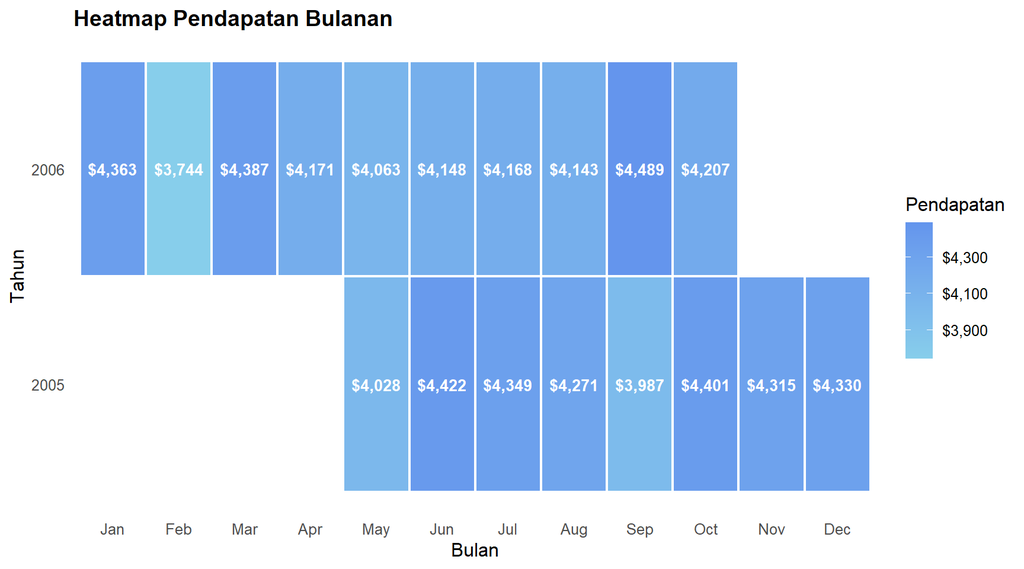

```r
heatmap_data <- dbGetQuery(con, "
  SELECT
    DATE_FORMAT(rental_date, '%Y')  AS tahun,
    DATE_FORMAT(rental_date, '%m')  AS bulan_num,
    ROUND(SUM(amount), 2)        AS pendapatan
  FROM rental_payment
  GROUP BY tahun, bulan_num
") |>
  mutate(
    bulan_label = month.abb[as.integer(bulan_num)],
    bulan_label = factor(bulan_label, levels = month.abb)
  )

ggplot(heatmap_data,
       aes(x = bulan_label, y = tahun, fill = pendapatan)) +
  geom_tile(color = "white", linewidth = 0.8) +
  geom_text(aes(label = paste0("$", scales::comma(pendapatan, accuracy = 1))),
            size = 3.5, color = "white", fontface = "bold") +
  scale_fill_gradient(low = "skyblue", high = "cornflowerblue",
                      labels = dollar_format()) +
  labs(
    title = "Heatmap Pendapatan Bulanan",
    x     = "Bulan",
    y     = "Tahun",
    fill  = "Pendapatan"
  ) +
  theme_minimal(base_size = 12) +
  theme(
    plot.title = element_text(face = "bold", size = 14),
    panel.grid = element_blank()
  )
```

# 7 Kategori Terlaris per Toko

[figure not shown]

```r
top_cat_store <- dbGetQuery(con, "
  SELECT
    'Toko ' || r.store_id AS toko,
    c.name                AS kategori,
    COUNT(r.rental_id)    AS jumlah_penyewaan,
    ROUND(SUM(r.amount), 2) AS pendapatan
  FROM rental_payment r
  JOIN category c ON r.category_id = c.category_id
  GROUP BY r.store_id, c.name
  ORDER BY r.store_id, pendapatan DESC
") |>
  group_by(toko) |>
  slice_max(order_by = pendapatan, n = 8) |>
  ungroup() |>
  mutate(kategori = fct_reorder(kategori, pendapatan))

ggplot(top_cat_store,
       aes(x = kategori, y = pendapatan, fill = factor(toko))) +
  geom_col(show.legend = FALSE, width = 0.7) +
  geom_text(aes(label = paste0("$", scales::comma(pendapatan))),
            hjust = -0.1, size = 3) +
  facet_wrap(~toko, scales = "free_y") +
  coord_flip() +
  scale_y_continuous(labels = dollar_format(),
                     expand = expansion(mult = c(0, 0.2))) +
  scale_fill_manual(values = c("cornflowerblue","#e8702a")) +
  labs(
    title    = "Top 8 Kategori Film per Toko (berdasarkan pendapatan)",
    x        = NULL,
    y        = "Pendapatan (USD)",
    caption  = "Sumber data : Dataset Sakila"
  ) +
  theme_minimal(base_size = 11) +
  theme(
    plot.title         = element_text(face = "bold", size = 13),
    panel.grid.major.y = element_blank(),
    strip.text         = element_text(face = "bold", size = 12)
  )
```

# 8 Segmentasi Pelanggan Berdasarkan Nilai Transaksi

```r
cust_seg <- dbGetQuery(con, "
  SELECT
    customer_id,
    COUNT(rental_id)       AS frekuensi,
    ROUND(SUM(amount), 2)  AS total_belanja,
    ROUND(AVG(amount), 2)  AS avg_belanja
  FROM rental_payment
  GROUP BY customer_id
") |>
  mutate(
    segmen = case_when(
      total_belanja >= quantile(total_belanja, 0.75) ~ "Platinum (Top 25%)",
      total_belanja >= quantile(total_belanja, 0.50) ~ "Gold (50–75%)",
      total_belanja >= quantile(total_belanja, 0.25) ~ "Silver (25–50%)",
      TRUE                                           ~ "Bronze (Bawah 25%)"
    ),
    segmen = factor(segmen,
                    levels = c("Platinum (Top 25%)","Gold (50–75%)",
                               "Silver (25–50%)","Bronze (Bawah 25%)"))
  )

seg_summary <- cust_seg |>
  group_by(segmen) |>
  summarise(
    jumlah_pelanggan = n(),
    total_pendapatan = sum(total_belanja),
    avg_belanja      = round(mean(total_belanja), 2),
    .groups          = "drop"
  ) |>
  mutate(
    pct_pelanggan  = round(jumlah_pelanggan / sum(jumlah_pelanggan) * 100, 1),
    pct_pendapatan = round(total_pendapatan / sum(total_pendapatan) * 100, 1)
  )

kable(seg_summary,
      col.names = c("Segmen","Pelanggan","Total Pendapatan (USD)",
                    "Rata-rata Belanja","% Pelanggan","% Pendapatan"),
      format.args = list(big.mark = ","),
      align = c("l","r","r","r","r","r")) |>
  kable_styling(bootstrap_options = c("striped","hover"),
                full_width = FALSE) |>
  row_spec(1, bold = TRUE, color = "white", background = "#c0952c")
```

| Segmen | Pelanggan | Total Pendapatan (USD) | Rata-rata Belanja | % Pelanggan | % Pendapatan |
| --- | --- | --- | --- | --- | --- |
| Platinum (Top 25%) | 150 | 24,912.57 | 166.08 | 25.0 | 32.8 |
| Gold (50–75%) | 150 | 20,365.08 | 135.77 | 25.0 | 26.8 |
| Silver (25–50%) | 149 | 17,314.57 | 116.21 | 24.9 | 22.8 |
| Bronze (Bawah 25%) | 150 | 13,394.94 | 89.30 | 25.0 | 17.6 |

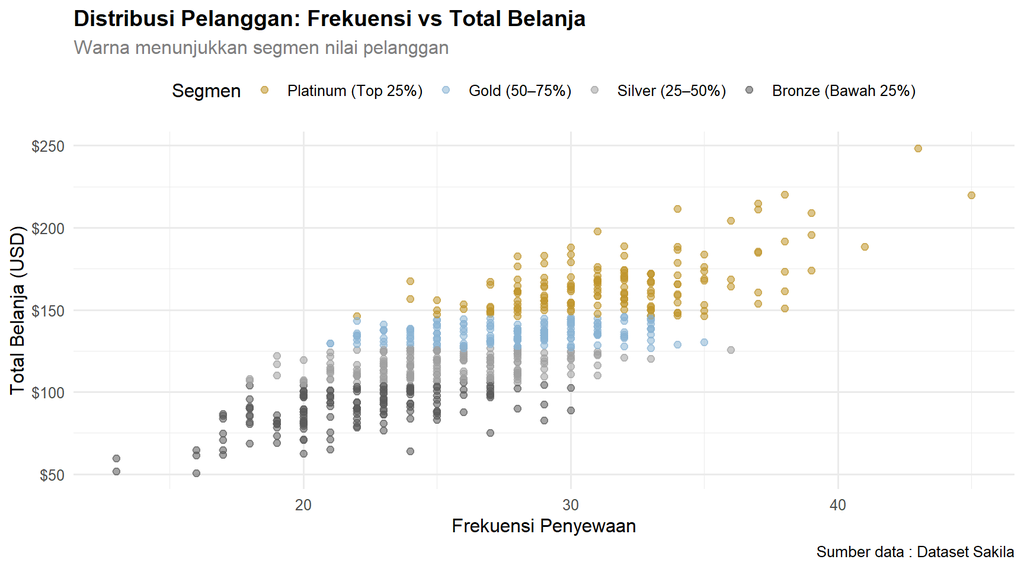

```r
ggplot(cust_seg, aes(x = frekuensi, y = total_belanja, color = segmen)) +
  geom_point(alpha = 0.55, size = 2) +
  scale_y_continuous(labels = dollar_format()) +
  scale_color_manual(values = c("#c0952c","#8ab4d4","#a0a0a0","#5a5a5a")) +
  labs(
    title    = "Distribusi Pelanggan: Frekuensi vs Total Belanja",
    subtitle = "Warna menunjukkan segmen nilai pelanggan",
    x        = "Frekuensi Penyewaan",
    y        = "Total Belanja (USD)",
    color    = "Segmen",
    caption  = "Sumber data : Dataset Sakila"
  ) +
  theme_minimal(base_size = 12) +
  theme(
    plot.title    = element_text(face = "bold", size = 14),
    plot.subtitle = element_text(color = "grey50"),
    legend.position = "top"
  )
```